# COS60008 Introduction to Data Science

## Assignment 3, 2024, Semester 1

## Srudent Details:

- Name: Pornkanok Tantewee
- Student ID: 103503476
- Email: 103503476@student.swin.edu.au
- Submission Date: 6 June 2024

Thirteen (13) clinical features:

- age: age of the patient (years)
- anaemia: decrease of red blood cells or hemoglobin (boolean)
- creatinine phosphokinase (CPK): level of the CPK enzyme in the blood (mcg/L)
- diabetes: if the patient has diabetes (boolean)
- ejection fraction: percentage of blood leaving the heart at each contraction (percentage)
- high blood pressure: if the patient has hypertension (boolean)
- platelets: platelets in the blood (kiloplatelets/mL)
- sex: woman or man (binary)
- serum creatinine: level of serum creatinine in the blood (mg/dL)
- serum sodium: level of serum sodium in the blood (mEq/L)
- smoking: if the patient smokes or not (boolean)
- time: follow-up period (days)
- [target] death event: if the patient died during the follow-up period (boolean)

## Task1-

## 1.1 Problem Formulation, Data Acquisition and Preparation

```python
import pandas as pd
import matplotlib.pyplot as plt
import numpy as np
import matplotlib.pyplot as plt
import seaborn as sns
import scipy.stats as stats
#Load the data
df_raw = pd.read_csv('heart.csv')
```

```python
df_raw
```

|  | age | anaemia | creatinine_phosphokinase | diabetes | ejection_fraction | high_blood_pressure | platelets | serum_creatinine | serum_sodium | sex | smoking | time | DEATH_EVENT |
| --- | --- | --- | --- | --- | --- | --- | --- | --- | --- | --- | --- | --- | --- |
| 0 | 75.0 | 0 | 582 | 0 | 20 | 1 | 265000.00 | 1.9 | 130 | 1 | 0 | 4 | 1 |
| 1 | 55.0 | 0 | 7861 | 0 | 38 | 0 | 263358.03 | 1.1 | 136 | 1 | 0 | 6 | 1 |
| 2 | 65.0 | 0 | 146 | 0 | 20 | 0 | 162000.00 | 1.3 | 129 | 1 | 1 | 7 | 1 |
| 3 | 50.0 | 1 | 111 | 0 | 20 | 0 | 210000.00 | 1.9 | 137 | 1 | 0 | 7 | 1 |
| 4 | 65.0 | 1 | 160 | 1 | 20 | 0 | 327000.00 | 2.7 | 116 | 0 | 0 | 8 | 1 |
| ... | ... | ... | ... | ... | ... | ... | ... | ... | ... | ... | ... | ... | ... |
| 294 | 62.0 | 0 | 61 | 1 | 38 | 1 | 155000.00 | 1.1 | 143 | 1 | 1 | 270 | 0 |
| 295 | 55.0 | 0 | 1820 | 0 | 38 | 0 | 270000.00 | 1.2 | 139 | 0 | 0 | 271 | 0 |
| 296 | 45.0 | 0 | 2060 | 1 | 60 | 0 | 742000.00 | 0.8 | 138 | 0 | 0 | 278 | 0 |
| 297 | 45.0 | 0 | 2413 | 0 | 38 | 0 | 140000.00 | 1.4 | 140 | 1 | 1 | 280 | 0 |
| 298 | 50.0 | 0 | 196 | 0 | 45 | 0 | 395000.00 | 1.6 | 136 | 1 | 1 | 285 | 0 |

299 rows × 13 columns

```python
 df_raw.info() # it is used for exploration
```

```
<class 'pandas.core.frame.DataFrame'>
RangeIndex: 299 entries, 0 to 298
Data columns (total 13 columns):
 #   Column                    Non-Null Count  Dtype
---  ------                    --------------  -----
 0   age                       299 non-null    float64
 1   anaemia                   299 non-null    int64
 2   creatinine_phosphokinase  299 non-null    int64
 3   diabetes                  299 non-null    int64
 4   ejection_fraction         299 non-null    int64
 5   high_blood_pressure       299 non-null    int64
 6   platelets                 299 non-null    float64
 7   serum_creatinine          299 non-null    float64
 8   serum_sodium              299 non-null    int64
 9   sex                       299 non-null    int64
 10  smoking                   299 non-null    int64
 11  time                      299 non-null    int64
 12  DEATH_EVENT               299 non-null    int64
dtypes: float64(3), int64(10)
memory usage: 30.5 KB
```

```python
# check unique of category data in each column
for col in df_raw.select_dtypes(include='int').columns:
    unique_values = df_raw[col].unique()
    print(f"Unique values in '{col}':")
    print(unique_values)
```

```
Unique values in 'anaemia':
[0 1]
Unique values in 'creatinine_phosphokinase':
[ 582 7861  146  111  160   47  246  315  157  123   81  231  981  168
   80  379  149  125   52  128  220   63  148  112  122   60   70   23
  249  159   94  855 2656  235  124  571  127  588 1380  553  129  577
   91 3964   69  260  371   75  607  789  364 7702  318  109   68  250
  110  161  113 5882  224   92  102  203  336   76   55  280   78   84
  115   66  897  154  144  133  514   59  156   61  305  898 5209   53
  328  748 1876  936  292  369  143  754  400   96  737  358  200  248
  270 1808 1082  719  193 4540  646  281 1548  805  291  482  943  185
  132 1610 2261  233   30 1846  335   58  910   72  130 2334 2442  776
  196  835 3966  171  198   95 1419  478  176  395   99  145  104 1896
  151  244   62  121  418  167 1211 1767  308   97   64  101  212 2281
  972  131  135 1202  427 1021  118   86  675   57 2794   56  211  166
```

[output cut: 28 more lines]

```python
df = df_raw.copy() # it is used for Spliiting data and model performing
```

```python
df_textreplace = df_raw.copy() #replace numerical datapoint by catagorical data.
```

```python
# handle by replace appropriate value
df_textreplace['anaemia'] = df_textreplace['anaemia'].replace(0, 'No')
df_textreplace['anaemia'] = df_textreplace['anaemia'].replace(1, 'Yes')
df_textreplace['diabetes'] = df_textreplace['diabetes'].replace(0, 'No')
df_textreplace['diabetes'] = df_textreplace['diabetes'].replace(1, 'Yes')
df_textreplace['high_blood_pressure'] = df_textreplace['high_blood_pressure'].replace(0, 'No')
df_textreplace['high_blood_pressure'] = df_textreplace['high_blood_pressure'].replace(1, 'Yes')
df_textreplace['sex'] = df_textreplace['sex'].replace(0, 'Woman')
df_textreplace['sex'] = df_textreplace['sex'].replace(1, 'Man')
df_textreplace['smoking'] = df_textreplace['smoking'].replace(0, 'No')
df_textreplace['smoking'] = df_textreplace['smoking'].replace(1, 'Yes')
df_textreplace['DEATH_EVENT'] = df_textreplace['DEATH_EVENT'].replace(0, 'No')
df_textreplace['DEATH_EVENT'] = df_textreplace['DEATH_EVENT'].replace(1, 'Yes')
```

```python
# check category data in each column
for col in df_textreplace.select_dtypes(include='object').columns:
    unique_values = df_textreplace[col].unique()
    print(f"Unique values in '{col}':")
    print(unique_values)
```

```
Unique values in 'anaemia':
['No' 'Yes']
Unique values in 'diabetes':
['No' 'Yes']
Unique values in 'high_blood_pressure':
['Yes' 'No']
Unique values in 'sex':
['Man' 'Woman']
Unique values in 'smoking':
['No' 'Yes']
Unique values in 'DEATH_EVENT':
['Yes' 'No']
```

```python
df_raw.isnull().sum()
```

```
age                         0
anaemia                     0
creatinine_phosphokinase    0
diabetes                    0
ejection_fraction           0
high_blood_pressure         0
platelets                   0
serum_creatinine            0
serum_sodium                0
sex                         0
smoking                     0
time                        0
DEATH_EVENT                 0
dtype: int64
```

## 1.2 Exploration

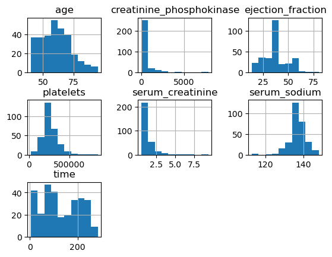

```python
df_textreplace.hist()
plt.subplots_adjust(wspace=0.5, hspace=0.5)
```

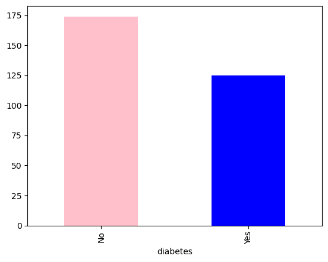

```python
df_textreplace['diabetes'].value_counts().plot(kind= 'bar', color= ['pink', 'blue'])
```

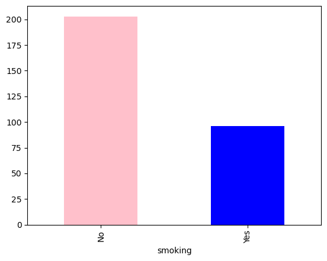

```python
df_textreplace['smoking'].value_counts().plot(kind= 'bar', color= ['pink', 'blue'])
```

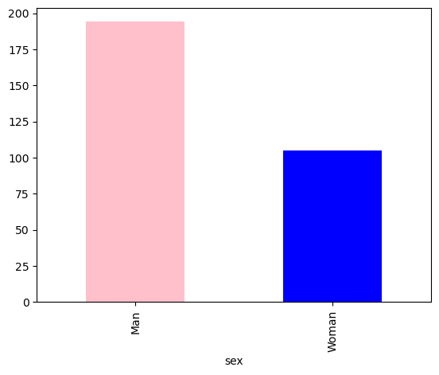

```python
df_textreplace['sex'].value_counts().plot(kind= 'bar', color= ['pink', 'blue'])
```

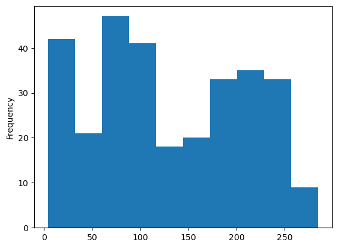

```python
df_textreplace['time'].plot(kind='hist');
```

```
                           age  anaemia  creatinine_phosphokinase  diabetes  \
age                       1.00     0.09                     -0.08     -0.10
anaemia                   0.09     1.00                     -0.19     -0.01
creatinine_phosphokinase -0.08    -0.19                      1.00     -0.01
diabetes                 -0.10    -0.01                     -0.01      1.00
ejection_fraction         0.06     0.03                     -0.04     -0.00
high_blood_pressure       0.09     0.04                     -0.07     -0.01
platelets                -0.05    -0.04                      0.02      0.09
serum_creatinine          0.16     0.05                     -0.02     -0.05
serum_sodium             -0.05     0.04                      0.06     -0.09
sex                       0.07    -0.09                      0.08     -0.16
smoking                   0.02    -0.11                      0.00     -0.15
time                     -0.22    -0.14                     -0.01      0.03
DEATH_EVENT               0.25     0.07                      0.06     -0.00

                          ejection_fraction  high_blood_pressure  platelets  \
age                                    0.06                 0.09      -0.05
anaemia                                0.03                 0.04      -0.04
creatinine_phosphokinase              -0.04                -0.07       0.02
diabetes                              -0.00                -0.01       0.09
ejection_fraction                      1.00                 0.02       0.07
high_blood_pressure                    0.02                 1.00       0.05
platelets                              0.07                 0.05       1.00
serum_creatinine                      -0.01                -0.00      -0.04
serum_sodium                           0.18                 0.04       0.06
sex                                   -0.15                -0.10      -0.13
smoking                               -0.07                -0.06       0.03
time                                   0.04                -0.20       0.01
DEATH_EVENT                           -0.27                 0.08      -0.05

                          serum_creatinine  serum_sodium   sex  smoking  time  \
age                                   0.16         -0.05  0.07     0.02 -0.22
anaemia                               0.05          0.04 -0.09    -0.11 -0.14
creatinine_phosphokinase             -0.02          0.06  0.08     0.00 -0.01
diabetes                             -0.05         -0.09 -0.16    -0.15  0.03
ejection_fraction                    -0.01          0.18 -0.15    -0.07  0.04
high_blood_pressure                  -0.00          0.04 -0.10    -0.06 -0.20
platelets                            -0.04          0.06 -0.13     0.03  0.01
serum_creatinine                      1.00         -0.19  0.01    -0.03 -0.15
serum_sodium                         -0.19          1.00 -0.03     0.00  0.09
sex                                   0.01         -0.03  1.00     0.45 -0.02
smoking                              -0.03          0.00  0.45     1.00 -0.02
time                                 -0.15          0.09 -0.02    -0.02  1.00
DEATH_EVENT                           0.29         -0.20 -0.00    -0.01 -0.53

                          DEATH_EVENT
age                              0.25
anaemia                          0.07
creatinine_phosphokinase         0.06
diabetes                        -0.00
ejection_fraction               -0.27
high_blood_pressure              0.08
platelets                       -0.05
serum_creatinine                 0.29
serum_sodium                    -0.20
sex                             -0.00
smoking                         -0.01
time                            -0.53
DEATH_EVENT                      1.00
```

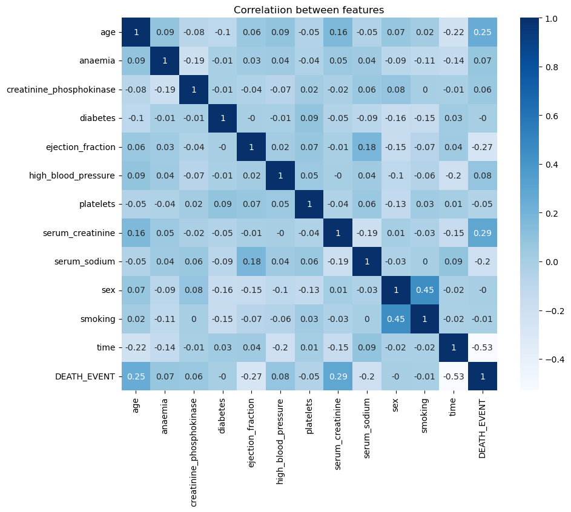

```python
#Check correlation to determine the relationship between features


correlation_matrix = df_raw.corr(numeric_only=True)
print(correlation_matrix.round(2))

#Plotting the correlations
plt.figure(figsize=(10,8))
sns.heatmap(correlation_matrix.round(2), annot=True, cmap='Blues')
plt.title("Correlatiion between features")
#plt.savefig(correlation_matrix.png")
```

```python
df_raw.columns
```

```
Index(['age', 'anaemia', 'creatinine_phosphokinase', 'diabetes',
       'ejection_fraction', 'high_blood_pressure', 'platelets',
       'serum_creatinine', 'serum_sodium', 'sex', 'smoking', 'time',
       'DEATH_EVENT'],
      dtype='object')
```

```python
coln=['age', 'creatinine_phosphokinase',
       'ejection_fraction', 'platelets',
       'serum_creatinine', 'serum_sodium','time']
```

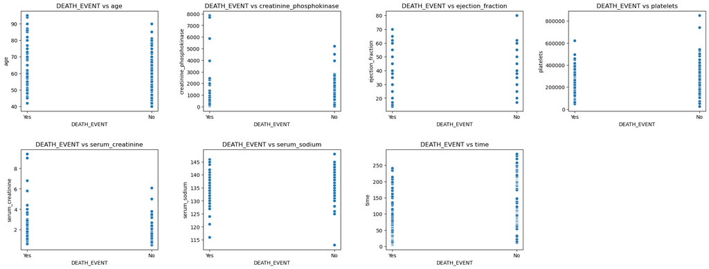

```python
# create picture in 2 row 4 columns
fig, axes = plt.subplots(nrows=2, ncols=4, figsize=(20, 8))

# make axes to array 1 demension
axes = axes.flatten()

# create scatter plot each column in coln
for i, col in enumerate(coln):
    sns.scatterplot(x='DEATH_EVENT', y=col, data=df_textreplace, ax=axes[i])
    axes[i].set_title(f'DEATH_EVENT vs {col}')
    axes[i].set_xlabel('DEATH_EVENT')
    axes[i].set_ylabel(col)

# hide axes that is not used
for j in range(len(coln), len(axes)):
    fig.delaxes(axes[j])

#  determine space distance between each graph
plt.tight_layout(pad=3.0, w_pad=3.0, h_pad=3.0)

# show graph
plt.show()
```

```python
df_textreplace.groupby(['DEATH_EVENT', 'sex']).count()
```

| DEATH_EVENT | sex | age | anaemia | creatinine_phosphokinase | diabetes | ejection_fraction | high_blood_pressure | platelets | serum_creatinine | serum_sodium | smoking | time |
| --- | --- | --- | --- | --- | --- | --- | --- | --- | --- | --- | --- | --- |
| No | Man | 132 | 132 | 132 | 132 | 132 | 132 | 132 | 132 | 132 | 132 | 132 |
|  | Woman | 71 | 71 | 71 | 71 | 71 | 71 | 71 | 71 | 71 | 71 | 71 |
| Yes | Man | 62 | 62 | 62 | 62 | 62 | 62 | 62 | 62 | 62 | 62 | 62 |
|  | Woman | 34 | 34 | 34 | 34 | 34 | 34 | 34 | 34 | 34 | 34 | 34 |

```python
df_textreplace.groupby(['DEATH_EVENT', 'sex']).count()
```

| DEATH_EVENT | sex | age | anaemia | creatinine_phosphokinase | diabetes | ejection_fraction | high_blood_pressure | platelets | serum_creatinine | serum_sodium | smoking | time |
| --- | --- | --- | --- | --- | --- | --- | --- | --- | --- | --- | --- | --- |
| No | Man | 132 | 132 | 132 | 132 | 132 | 132 | 132 | 132 | 132 | 132 | 132 |
|  | Woman | 71 | 71 | 71 | 71 | 71 | 71 | 71 | 71 | 71 | 71 | 71 |
| Yes | Man | 62 | 62 | 62 | 62 | 62 | 62 | 62 | 62 | 62 | 62 | 62 |
|  | Woman | 34 | 34 | 34 | 34 | 34 | 34 | 34 | 34 | 34 | 34 | 34 |

### 1.What is the impact of high blood pressure on the survival rate of heart failure patients?

```python
# Descriptive Statistics
blood_pressure_counts = df_textreplace['high_blood_pressure'].value_counts()

# Count of survived and deceased patients
survival_counts = df_textreplace['DEATH_EVENT'].value_counts()



#  summary statistics
print("Count of patients with and without high blood pressure:")
print(blood_pressure_counts)
print("\nCount of survived and deceased patients:")
print(survival_counts)

# Inferential Statistics:
# For inferential statistics,  want to test the null hypothesis that there is no difference in survival rates between patients with and without high blood pressure. It can be used a chi-square test to assess the association between high blood pressure and survival outcome.



# Create a contingency table of blood pressure status vs. survival outcome
contingency_table = pd.crosstab(df_raw['high_blood_pressure'], df_raw['DEATH_EVENT'])


# Perform chi-square test of independence
chi2, p, dof, expected = stats.chi2_contingency(contingency_table)
# Display the results

print("P-value:", p)


#  significance level=0.05
```

```
Count of patients with and without high blood pressure:
high_blood_pressure
No     194
Yes    105
Name: count, dtype: int64

Count of survived and deceased patients:
DEATH_EVENT
No     203
Yes     96
Name: count, dtype: int64
P-value: 0.21410341199416902
```

```
data grouping and counting for each group of DEATH_EVENT
high_blood_pressure  DEATH_EVENT
No                   No             137
                     Yes             57
Yes                  No              66
                     Yes             39
dtype: int64
```

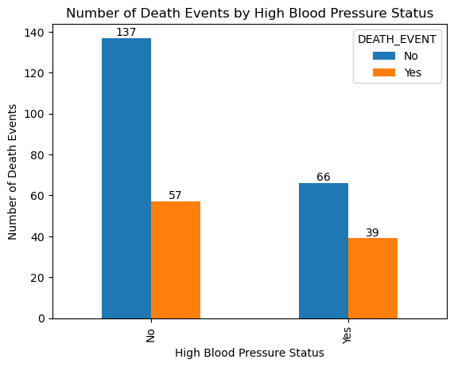

```python
# data grouping and counting for each group of DEATH_EVENT
count_by_hbp = df_textreplace.groupby(['high_blood_pressure', 'DEATH_EVENT']).size()
print('data grouping and counting for each group of DEATH_EVENT')
print(count_by_hbp)


# group High Blood Pressure by DEATH_EVENT
count_by_hbp = df_textreplace.groupby(['high_blood_pressure', 'DEATH_EVENT']).size().unstack()

# plot unstack bar graph
ax = count_by_hbp.plot(kind='bar', stacked=False)

# add number on bar
for container in ax.containers:
    ax.bar_label(container, label_type='edge')

ax.set_title('Number of Death Events by High Blood Pressure Status')
ax.set_xlabel('High Blood Pressure Status')
ax.set_ylabel('Number of Death Events')


#  plot graph
plt.show()
```

Answers: Descriptive Observation: The bar graph visually shows that a higher proportion of heart failure patients without high blood pressure survived compared to those with high blood pressure. Statistical Analysis: Despite the observed differences, resulted in a p-value of 0.214, indicating no statistically significant association between high blood pressure and survival rate at the conventional 0.05 significance level

```python
df_raw.columns
```

```
Index(['age', 'anaemia', 'creatinine_phosphokinase', 'diabetes',
       'ejection_fraction', 'high_blood_pressure', 'platelets',
       'serum_creatinine', 'serum_sodium', 'sex', 'smoking', 'time',
       'DEATH_EVENT'],
      dtype='object')
```

### 2.How does the ejection fraction vary between males and females?

The boxplot will display the distribution of ejection fraction for male (represented by 1) and female (represented by 0) patients.

```
Descriptive Statistics for Ejection Fraction by Sex:
       count       mean        std   min   25%   50%   75%   max
sex
Man    194.0  36.793814  11.144308  14.0  30.0  35.0  40.0  62.0
Woman  105.0  40.466667  12.728728  15.0  30.0  38.0  50.0  80.0

Count of patients by sex:
sex
Man      194
Woman    105
Name: count, dtype: int64
```

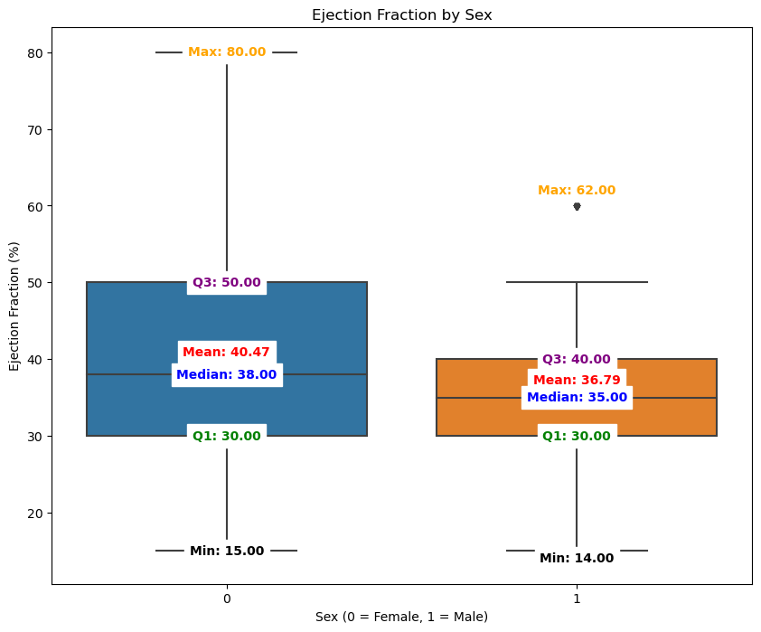

```python
# Descriptive Statistics
ejection_fraction_desc_by_sex = df_textreplace.groupby('sex')['ejection_fraction'].describe()
count_by_sex = df_textreplace['sex'].value_counts()

print("Descriptive Statistics for Ejection Fraction by Sex:")
print(ejection_fraction_desc_by_sex)
print("\nCount of patients by sex:")
print(count_by_sex)

# Boxplot for sex vs. ejection fraction
plt.figure(figsize=(10, 8))
ax = sns.boxplot(x='sex', y='ejection_fraction', data=df_raw)
plt.title('Ejection Fraction by Sex')
plt.xlabel('Sex (0 = Female, 1 = Male)')
plt.ylabel('Ejection Fraction (%)')

# Adding descriptive statistics to the boxplot
desc_stats = df_raw.groupby('sex')['ejection_fraction'].describe()
mean_values = desc_stats['mean'].values
median_values = desc_stats['50%'].values
q1_values = desc_stats['25%'].values
q3_values = desc_stats['75%'].values
min_values = desc_stats['min'].values
max_values = desc_stats['max'].values

# Positioning the text above the boxplot
positions = range(len(mean_values))
for pos, mean, median, q1, q3, min_val, max_val in zip(positions, mean_values, median_values, q1_values, q3_values, min_values, max_values):
    ax.text(pos, mean, f'Mean: {mean:.2f}', horizontalalignment='center', color='red', weight='semibold', backgroundcolor='white')
    ax.text(pos, median, f'Median: {median:.2f}', horizontalalignment='center', color='blue', weight='semibold', backgroundcolor='white', verticalalignment='center')
    ax.text(pos, q1, f'Q1: {q1:.2f}', horizontalalignment='center', color='green', weight='semibold', backgroundcolor='white', verticalalignment='center')
    ax.text(pos, q3, f'Q3: {q3:.2f}', horizontalalignment='center', color='purple', weight='semibold', backgroundcolor='white', verticalalignment='center')
    ax.text(pos, min_val, f'Min: {min_val:.2f}', horizontalalignment='center', color='black', weight='semibold', backgroundcolor='white', verticalalignment='center')
    ax.text(pos, max_val, f'Max: {max_val:.2f}', horizontalalignment='center', color='orange', weight='semibold', backgroundcolor='white', verticalalignment='center')

plt.show()
```

```python
# Inferential Statistics
# Independent samples t-test
female_ejection_fraction = df_raw[df_raw['sex'] == 0]['ejection_fraction']
male_ejection_fraction = df_raw[df_raw['sex'] == 1]['ejection_fraction']

t_stat, p_value = stats.ttest_ind(female_ejection_fraction, male_ejection_fraction)

print(f"Independent Samples T-test Results:")
print(f"T-statistic: {t_stat}")
print(f"P-value: {p_value}")

if p_value < 0.05:
    print("There is a statistically significant difference in ejection fraction between males and females.")
else:
    print("There is no statistically significant difference in ejection fraction between males and females.")
```

```
Independent Samples T-test Results:
T-statistic: 2.585864165814152
P-value: 0.010189690578840916
There is a statistically significant difference in ejection fraction between males and females.
```

Ans: The boxplot illustrates that females generally have higher ejection fractions with more variability.

Observing the T-test at a confidence level of 95%,, it is evident that differences in ejection fraction between males and females are statistically significant.

Thus, ejection fraction varies significantly between males and females, with females generally having higher ejection fractions.

### 3.How do serum creatinine levels affect the survival rate of heart failure patients?

```python
df_raw['serum_creatinine'] = df_raw['serum_creatinine'].astype('category')
```

```python
creatinine_survival = df_raw.groupby('serum_creatinine')['DEATH_EVENT'].apply(lambda x: 1 - x.mean()).reset_index()
creatinine_survival.columns = ['serum_creatinine', 'survival_rate']
```

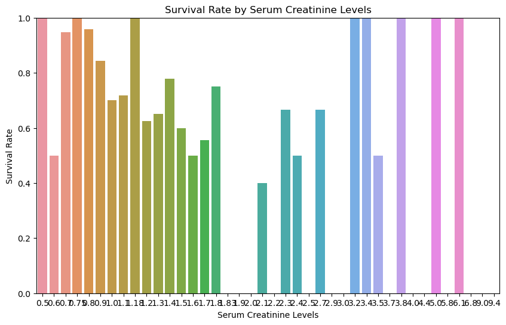

```
   serum_creatinine  survival_rate
0              0.50       1.000000
1              0.60       0.500000
2              0.70       0.947368
3              0.75       1.000000
4              0.80       0.958333
5              0.90       0.843750
6              1.00       0.700000
7              1.10       0.718750
8              1.18       1.000000
9              1.20       0.625000
10             1.30       0.650000
11             1.40       0.777778
12             1.50       0.600000
13             1.60       0.500000
```

[output cut: 26 more lines]

```python
plt.figure(figsize=(10, 6))
sns.barplot(x='serum_creatinine', y='survival_rate', data=creatinine_survival)
plt.title('Survival Rate by Serum Creatinine Levels')
plt.xlabel('Serum Creatinine Levels')
plt.ylabel('Survival Rate')
plt.ylim(0, 1)
plt.show()

# Print the survival rates
print(creatinine_survival)
```

```python
df_raw['serum_creatinine'].isna().sum()
```

```
0
```

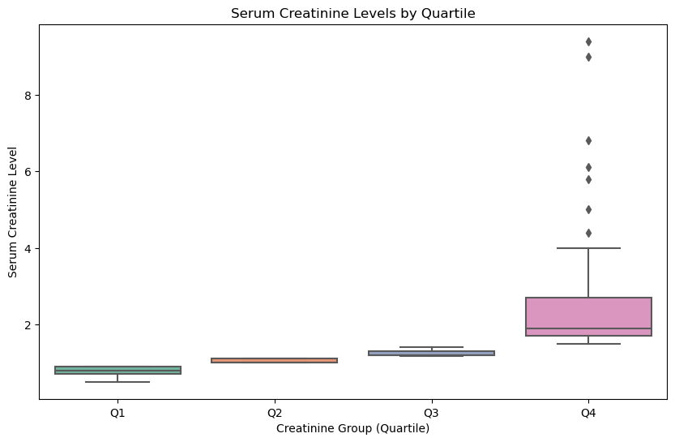

```python
# Ensure 'serum_creatinine' is numeric
df_raw['serum_creatinine'] = pd.to_numeric(df_raw['serum_creatinine'], errors='coerce')

# Create serum creatinine groups (quartiles)
df_raw['creatinine_group'] = pd.qcut(df_raw['serum_creatinine'], q=4, labels=['Q1', 'Q2', 'Q3', 'Q4'])

# Create a box plot to visualize the serum creatinine levels in each quartile
plt.figure(figsize=(10, 6))
sns.boxplot(x='creatinine_group', y='serum_creatinine', data=df_raw, palette='Set2')
plt.title('Serum Creatinine Levels by Quartile')
plt.xlabel('Creatinine Group (Quartile)')
plt.ylabel('Serum Creatinine Level')
plt.show()
```

```
float64
[1.9  1.1  1.3  2.7  2.1  1.2  1.5  9.4  4.   0.9  1.   0.8  1.6  1.83
 5.8  3.   3.5  2.3  0.6  4.4  1.4  6.8  2.2  2.   1.18 2.9  0.7  1.7
 2.5  1.8  3.2  0.75 3.7  3.4  6.1  2.4  9.   5.   0.5  3.8 ]
```

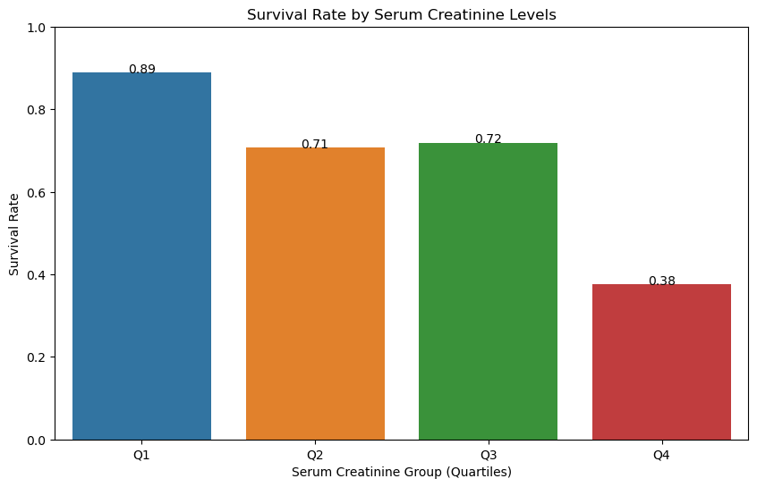

```
  creatinine_group  survival_rate
0               Q1       0.888889
1               Q2       0.707317
2               Q3       0.718750
3               Q4       0.375000
```

```python
# Check the data type of the 'serum_creatinine' column
print(df_raw['serum_creatinine'].dtype)

# Inspect the 'serum_creatinine' column for non-numeric values
print(df_raw['serum_creatinine'].unique())

# Convert the 'serum_creatinine' column to numeric, coercing errors
df_raw['serum_creatinine'] = pd.to_numeric(df_raw['serum_creatinine'], errors='coerce')


# Create serum creatinine groups (quartiles)
df_raw['creatinine_group'] = pd.qcut(df_raw['serum_creatinine'], q=4, labels=['Q1', 'Q2', 'Q3', 'Q4'])

# Calculate survival rate for each serum creatinine group
creatinine_survival = df_raw.groupby('creatinine_group')['DEATH_EVENT'].apply(lambda x: 1 - x.mean()).reset_index()
creatinine_survival.columns = ['creatinine_group', 'survival_rate']



# Plot the survival rates
plt.figure(figsize=(10, 6))
sns.barplot(x='creatinine_group', y='survival_rate', data=creatinine_survival)

# Add number on bar
for index, row in creatinine_survival.iterrows():
    plt.text(row.name, row.survival_rate, f'{row.survival_rate:.2f}', color='black', ha="center")

plt.title('Survival Rate by Serum Creatinine Levels')
plt.xlabel('Serum Creatinine Group (Quartiles)')
plt.ylabel('Survival Rate')
plt.ylim(0, 1)
plt.show()

# Print the survival rates
print(creatinine_survival)
```

The provided data shows the survival rates of heart failure patients categorized by serum creatinine levels (creatinine_group).

Higher serum creatinine levels are associated with lower survival rates: Patients in the highest quartile (Q4) of serum creatinine levels have the lowest survival rate of 37.5%. This suggests that higher serum creatinine levels are correlated with poorer survival outcomes among heart failure patients. Lower serum creatinine levels are associated with higher survival rates:

Conversely, patients in the lowest quartile (Q1) of serum creatinine levels have the highest survival rate of 88.9%. This indicates that lower serum creatinine levels are associated with better survival outcomes among heart failure patients. Intermediate levels show intermediate survival rates:

Overall, these findings suggest that there is a negative correlation between serum creatinine levels and survival rates among heart failure patients. Higher serum creatinine levels tend to be associated with poorer survival outcomes, while lower levels are associated with better survival rates. This information can be valuable for risk stratification and clinical management of heart failure patients, as it highlights the importance of monitoring and managing serum creatinine levels in patient care.

## 1.3 Modelling

```python
df.columns
```

```
Index(['age', 'anaemia', 'creatinine_phosphokinase', 'diabetes',
       'ejection_fraction', 'high_blood_pressure', 'platelets',
       'serum_creatinine', 'serum_sodium', 'sex', 'smoking', 'time',
       'DEATH_EVENT'],
      dtype='object')
```

```python
from sklearn.model_selection import train_test_split ,cross_val_score
df.shape
print('shape before split')
print(df.shape)
#
X=df[['age','anaemia', 'creatinine_phosphokinase', 'diabetes',
       'ejection_fraction', 'high_blood_pressure', 'platelets',
       'serum_creatinine', 'serum_sodium', 'sex', 'smoking', 'time']]
y=df['DEATH_EVENT']
```

```
shape before split
(299, 13)
```

```python
# split data 80% for training set and 20% for testing set

X_train, X_test, y_train, y_test = train_test_split(X, y, test_size=0.2, random_state=1)
```

```python
# check complete splitting
len_X_train = len(X_train)
len_X_test = len(X_test)
len_y_train = len(y_train)
len_y_test = len(y_test)
print("X_train length:", len_X_train)
print("X_test length:", len_X_test)
print("y_train length:", len_y_train)
print("y_test length:", len_y_test)
```

```
X_train length: 239
X_test length: 60
y_train length: 239
y_test length: 60
```

```python
# Standardize the features
from sklearn.preprocessing import StandardScaler
scaler = StandardScaler()
X_train = scaler.fit_transform(X_train)
X_test = scaler.transform(X_test)
```

#### Model 1: K-Nearest Neighbors (K-NN)

```python
from sklearn import datasets
from sklearn.neighbors import KNeighborsClassifier
from sklearn.metrics import confusion_matrix, accuracy_score,precision_score, recall_score, f1_score
#Create a KNN model (see the KNeighborsClassifier class in sklearn.neighbors) and train
#it (using “fit”) on the training set with K = 11 (the neighbours value, n_neighbors)
knn = KNeighborsClassifier(n_neighbors=11)
knn.fit(X_train, y_train)
```

```
KNeighborsClassifier(n_neighbors=11)
```

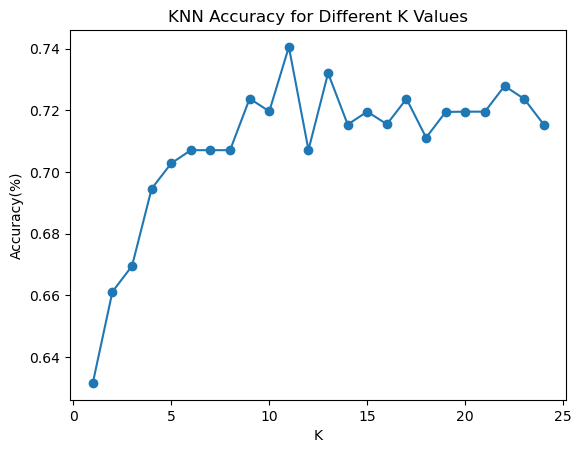

```
Best K: 11
```

```python
from sklearn.model_selection import cross_val_score, StratifiedKFold


# Determine hyperparameter values
#Using the stratified 5-fold cross-validation to identify the best value of the hyper-parameter

# Define the range of k values
k_values = range(1, 25)

# Create a list to store the accuracy scores for each K value
accuracy_scores = []

# Perform Cross-validation for each K value
for k in k_values:
    # Create a KNN classifier with the current K value
    knn = KNeighborsClassifier(n_neighbors=k)

    # Perform 5-fold Cross-validation
    skf = StratifiedKFold(n_splits=5)
    scores = cross_val_score(knn, X_train, y_train, cv=skf, scoring='accuracy')

    # Append the mean accuracy score to the list
    accuracy_scores.append(scores.mean())

# Plot the accuracy scores for different K values
plt.plot(k_values, accuracy_scores, marker='o')
plt.xlabel('K')
plt.ylabel('Accuracy(%)')
plt.title('KNN Accuracy for Different K Values')
plt.show()

# Select the K value with the highest accuracy
best_k = k_values[np.argmax(accuracy_scores)]
print("Best K:", best_k)
```

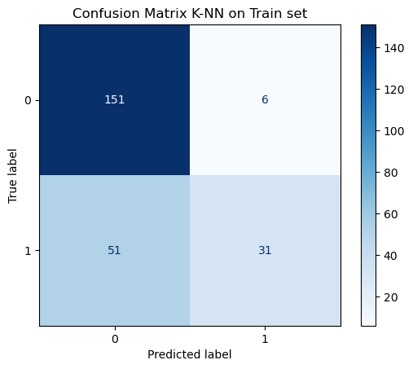

```
Precisionknn1_train: 0.7785108319720359
Recallknn_train : 0.7615062761506276
F1 avg_weight: 0.7313603032383219
accuracyknn_train
0.7615062761506276
conf_matrix_train
[[151   6]
 [ 51  31]]
precisionknn_train: 0.7785108319720359
Recallknn_train: 0.7615062761506276
F1-score knn_train: 0.7313603032383219
```

```python
# create model
knn = KNeighborsClassifier(n_neighbors=11)
knn.fit(X_train, y_train)
#Evalueate the performance of the trained model on the train set in KNN
y_predknn_train = knn.predict(X_train)
accuracyknn_train = accuracy_score(y_train, y_predknn_train)
conf_matrix_train = confusion_matrix(y_train, y_predknn_train)

# visual confusion matrix in heatmap
from sklearn.metrics import ConfusionMatrixDisplay
import matplotlib.pyplot as plt
disp= ConfusionMatrixDisplay(confusion_matrix=conf_matrix_train, display_labels=knn.classes_)
disp.plot(cmap=plt.cm.Blues)
plt.title('Confusion Matrix K-NN on Train set')
plt.show()
#Precision

precisionknn_train = precision_score(y_train, y_predknn_train, average='weighted')
print("Precisionknn1_train:", precisionknn_train)

# Recall

recallknn_train = recall_score(y_train, y_predknn_train, average='weighted')

print("Recallknn_train :", recallknn_train)

#F1 score

f1knn_train = f1_score(y_train, y_predknn_train, average='weighted')


print("F1 avg_weight:",f1knn_train)

print("accuracyknn_train")
print(accuracyknn_train)
print("conf_matrix_train")
print(conf_matrix_train)
print("precisionknn_train:", precisionknn_train)
print("Recallknn_train:", recallknn_train)
print("F1-score knn_train:", f1knn_train)
```

```
confusion matrix:
[[44  2]
 [10  4]]
accuracy test
0.8
```

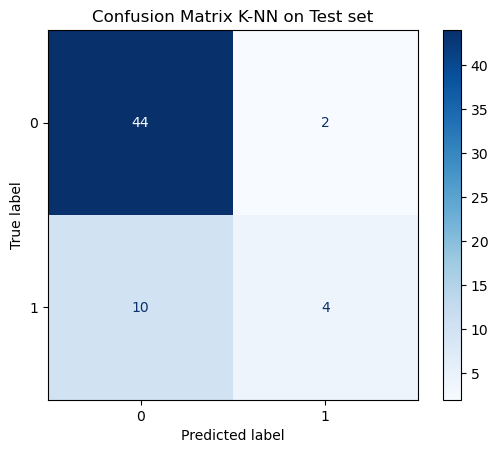

```
Precision test: 0.7802469135802468
Recall test: 0.8
F1-score test: 0.768
```

```python
#Evalueate the performance of the trained model on the test set in KNN before strandardisation
y_predknn_test = knn.predict(X_test)
conf_matrix_test = confusion_matrix(y_test, y_predknn_test)
accuracyknn_test = accuracy_score(y_test, y_predknn_test)
print("confusion matrix:")
print(conf_matrix_test)
print("accuracy test")
print(accuracyknn_test)

# visual confusion matrix in heatmap
from sklearn.metrics import ConfusionMatrixDisplay
import matplotlib.pyplot as plt
disp= ConfusionMatrixDisplay(confusion_matrix=conf_matrix_test, display_labels=knn.classes_)
disp.plot(cmap=plt.cm.Blues)
plt.title('Confusion Matrix K-NN on Test set')
plt.show()

#Precision

precisionknn_test = precision_score(y_test, y_predknn_test, average='weighted')
print("Precision test:", precisionknn_test)

# Recall

recallknn_test = recall_score(y_test, y_predknn_test, average='weighted')

print("Recall test:", recallknn_test)

#F1 score

f1knn_test = f1_score(y_test, y_predknn_test, average='weighted')


print("F1-score test:",f1knn_test)
```

```python
# display missing of model prediction in test set
dx=pd.DataFrame({'y_true': y_test, 'y_pred': y_predknn_test})
dx[dx.y_true != dx.y_pred]
```

|  | y_true | y_pred |
| --- | --- | --- |
| 51 | 1 | 0 |
| 119 | 1 | 0 |
| 11 | 1 | 0 |
| 110 | 1 | 0 |
| 105 | 1 | 0 |
| 12 | 1 | 0 |
| 18 | 1 | 0 |
| 131 | 0 | 1 |
| 78 | 0 | 1 |
| 58 | 1 | 0 |
| 185 | 1 | 0 |
| 150 | 1 | 0 |

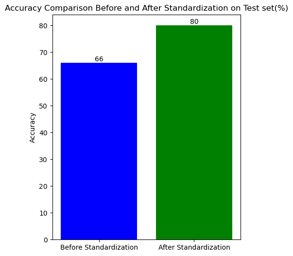

```python
#Plot accuracy comparison

labels = ['Before Standardization', 'After Standardization']
accuracy_scores = [66, 80]

# Plot graph
plt.figure(figsize=(5, 6))
bars = plt.bar(labels, accuracy_scores, color=['blue', 'green'])

# Number on bar
for bar in bars:
    yval = bar.get_height()
    plt.text(bar.get_x() + bar.get_width()/2, yval, round(yval, 2), ha='center', va='bottom')

#  labels and title
plt.ylabel('Accuracy')
plt.title('Accuracy Comparison Before and After Standardization on Test set(%)')

plt.show()
```

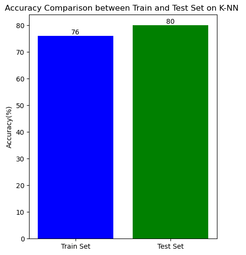

```python
#Plot accuracy comparison

labels = ['Train Set', 'Test Set']
accuracy_scores =[ 76, 80]

# Plot graph
plt.figure(figsize=(5, 6))
bars = plt.bar(labels, accuracy_scores, color=['blue', 'green'])

# Number on bar
for bar in bars:
    yval = bar.get_height()
    plt.text(bar.get_x() + bar.get_width()/2, yval, round(yval, 2), ha='center', va='bottom')

#  labels and title
plt.ylabel('Accuracy(%)')
plt.title('Accuracy Comparison between Train and Test Set on K-NN ')

plt.show()
```

```python
df_raw.head()
```

|  | age | anaemia | creatinine_phosphokinase | diabetes | ejection_fraction | high_blood_pressure | platelets | serum_creatinine | serum_sodium | sex | smoking | time | DEATH_EVENT | creatinine_group |
| --- | --- | --- | --- | --- | --- | --- | --- | --- | --- | --- | --- | --- | --- | --- |
| 0 | 75.0 | 0 | 582 | 0 | 20 | 1 | 265000.00 | 1.9 | 130 | 1 | 0 | 4 | 1 | Q4 |
| 1 | 55.0 | 0 | 7861 | 0 | 38 | 0 | 263358.03 | 1.1 | 136 | 1 | 0 | 6 | 1 | Q2 |
| 2 | 65.0 | 0 | 146 | 0 | 20 | 0 | 162000.00 | 1.3 | 129 | 1 | 1 | 7 | 1 | Q3 |
| 3 | 50.0 | 1 | 111 | 0 | 20 | 0 | 210000.00 | 1.9 | 137 | 1 | 0 | 7 | 1 | Q4 |
| 4 | 65.0 | 1 | 160 | 1 | 20 | 0 | 327000.00 | 2.7 | 116 | 0 | 0 | 8 | 1 | Q4 |

#### Model 2: Decision Tree

```python
# Determine hyperparameter values
#Using the stratified 5-fold cross-validation to identify the best value of the hyper-parameter
#max_depth.
from sklearn.model_selection import cross_val_score
depths = [1,3,5,7,9,11,15,17,19,21]
print(depths) ##

#Create a loop, and for each value of depths, get the cross-validation scores (for “accuracy”) and
#save the mean(). (i.e. append to a list called cv_scores).
from sklearn.tree import DecisionTreeClassifier
cv_scores=[]
#Loop over the depths
for depth in depths:
    dt = DecisionTreeClassifier(max_depth=depth)
    # Perform cross-validation
    scores = cross_val_score(dt, X_train, y_train, cv=10, scoring='accuracy')
    cv_scores.append(scores.mean())

    print(f"d: {depth},acc: {scores}, mean_acc: {scores.mean()}")
```

```
[1, 3, 5, 7, 9, 11, 15, 17, 19, 21]
d: 1,acc: [0.83333333 0.83333333 0.83333333 0.875      0.875      0.70833333
 0.91666667 0.79166667 0.83333333 0.91304348], mean_acc: 0.8413043478260869
d: 3,acc: [0.875      0.75       0.875      0.79166667 0.875      0.75
 0.79166667 0.70833333 0.83333333 0.7826087 ], mean_acc: 0.8032608695652174
d: 5,acc: [0.83333333 0.75       0.70833333 0.83333333 0.875      0.875
 0.70833333 0.66666667 0.875      0.86956522], mean_acc: 0.7994565217391305
d: 7,acc: [0.875      0.79166667 0.70833333 0.75       0.75       0.79166667
 0.66666667 0.625      0.83333333 0.91304348], mean_acc: 0.7704710144927536
d: 9,acc: [0.79166667 0.79166667 0.75       0.79166667 0.75       0.83333333
 0.70833333 0.625      0.79166667 0.86956522], mean_acc: 0.7702898550724638
d: 11,acc: [0.75       0.79166667 0.79166667 0.70833333 0.75       0.79166667
 0.70833333 0.625      0.83333333 0.86956522], mean_acc: 0.7619565217391304
d: 15,acc: [0.75       0.79166667 0.70833333 0.75       0.70833333 0.75
 0.70833333 0.625      0.79166667 0.82608696], mean_acc: 0.7409420289855073
d: 17,acc: [0.875      0.79166667 0.75       0.75       0.75       0.79166667
 0.70833333 0.625      0.83333333 0.82608696], mean_acc: 0.7701086956521739
d: 19,acc: [0.83333333 0.79166667 0.70833333 0.79166667 0.75       0.83333333
 0.66666667 0.58333333 0.83333333 0.82608696], mean_acc: 0.7617753623188406
d: 21,acc: [0.79166667 0.79166667 0.70833333 0.75       0.75       0.75
 0.70833333 0.625      0.79166667 0.86956522], mean_acc: 0.7536231884057971
```

```python
# cv_scores has the mean accuracy results, figure out what index has the best, and use
#that index in the depths list (i.e. find the max_depth_best).

print("cv_scores:", cv_scores)
#get the indice of the maximum value, so we know the best
max_depth_best = depths[np.argmax(cv_scores)]

print("max_depth_best:",max_depth_best)
```

```
cv_scores: [0.8413043478260869, 0.8032608695652174, 0.7994565217391305, 0.7704710144927536, 0.7702898550724638, 0.7619565217391304, 0.7409420289855073, 0.7701086956521739, 0.7617753623188406, 0.7536231884057971]
max_depth_best: 1
```

The best max depth is 1 provide average accuracy 84%

```python
# Train a decision tree model by using the best max_depth
dt_best = DecisionTreeClassifier(max_depth=max_depth_best, random_state=1)
dt_best.fit(X_train, y_train)
```

```
DecisionTreeClassifier(max_depth=1, random_state=1)
```

```
Confusion Matrix:
 [[147  10]
 [ 28  54]]
AccuracyT_train: 0.8410041841004184
```

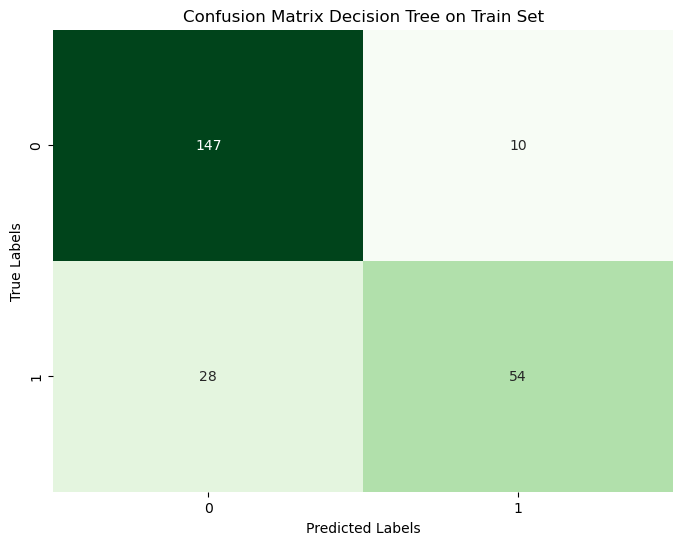

```
PrecisionT train: 0.8412866108786611
Recall train: 0.8410041841004184
F1-score train: 0.8355131997008496
```

```python
# Evaluate the performance of the trained model on the train set
y_predT_train = dt_best.predict(X_train)
conf_matrixT_train = confusion_matrix(y_train, y_predT_train)
accuracyT_train = accuracy_score(y_train, y_predT_train)

print("Confusion Matrix:\n",conf_matrixT_train)
print("AccuracyT_train:", accuracyT_train)

# Plot confusion matrix as heatmap
plt.figure(figsize=(8, 6))
sns.heatmap(conf_matrixT_train, annot=True, fmt="d", cmap="Greens", cbar=False)
plt.title("Confusion Matrix Decision Tree on Train Set")
plt.xlabel("Predicted Labels")
plt.ylabel("True Labels")
plt.show()

#Precision

precisionT_train = precision_score(y_train, y_predT_train, average='weighted')

print("PrecisionT train:", precisionT_train)

# Recall

recallT_train = recall_score(y_train, y_predT_train, average='weighted')

print("Recall train:", recallT_train)

#F1 score

f1T_train = f1_score(y_train, y_predT_train, average='weighted')

print("F1-score train:",f1T_train)
```

```
Confusion Matrix:
 [[43  3]
 [ 5  9]]
AccuracyT: 0.8666666666666667
```

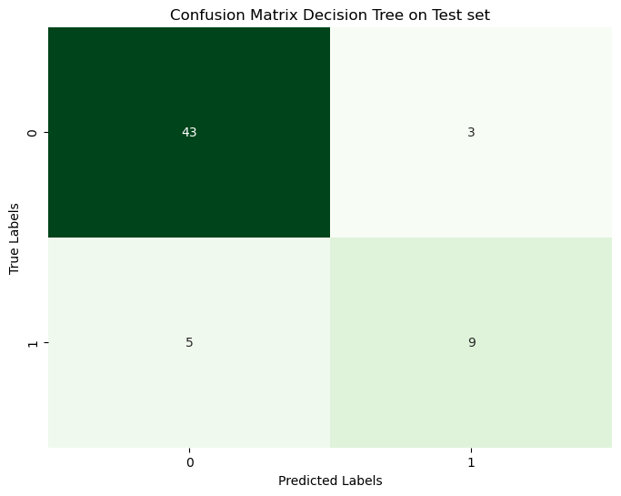

```
PrecisionT test: 0.8618055555555556
Recall test: 0.8666666666666667
F1-score test: 0.8629569012547736
```

```python
# Evaluate the performance of the trained model on the test set
y_predT_test = dt_best.predict(X_test)
conf_matrixT_test = confusion_matrix(y_test, y_predT_test)
accuracyT_test = accuracy_score(y_test, y_predT_test)

print("Confusion Matrix:\n",conf_matrixT_test)
print("AccuracyT:", accuracyT_test)

# Plot confusion matrix as heatmap
plt.figure(figsize=(8, 6))
sns.heatmap(conf_matrixT_test, annot=True, fmt="d", cmap="Greens", cbar=False)
plt.title("Confusion Matrix Decision Tree on Test set")
plt.xlabel("Predicted Labels")
plt.ylabel("True Labels")
plt.show()

#Precision

precisionT_test = precision_score(y_test, y_predT_test, average='weighted')

print("PrecisionT test:", precisionT_test)

# Recall

recallT_test = recall_score(y_test, y_predT_test, average='weighted')

print("Recall test:", recallT_test)

#F1 score

f1T_test = f1_score(y_test, y_predT_test, average='weighted')

print("F1-score test:",f1T_test)
```

[output not shown]

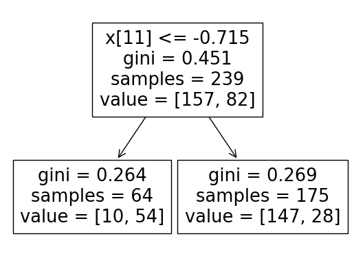

```python
from sklearn import tree
tree.plot_tree(dt_best)
```

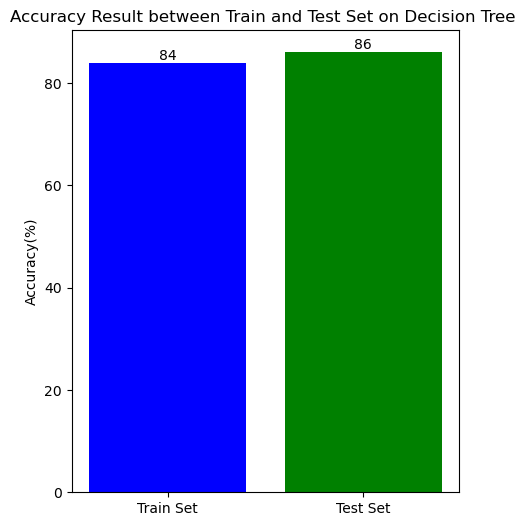

```python
#Plot accuracy comparison

labels = ['Train Set', 'Test Set']
accuracy_scores =[ 84, 86]

# Plot graph
plt.figure(figsize=(5, 6))
bars = plt.bar(labels, accuracy_scores, color=['blue', 'green'])

# Number on bar
for bar in bars:
    yval = bar.get_height()
    plt.text(bar.get_x() + bar.get_width()/2, yval, round(yval, 2), ha='center', va='bottom')

#  labels and title
plt.ylabel('Accuracy(%)')
plt.title('Accuracy Result between Train and Test Set on Decision Tree ')

plt.show()
```

The model's accuracy on the training set is slightly lower than its accuracy on the testing set. This indicates that the model generalizes well to unseen data and is a good fit. The consistent performance across both the training and testing sets suggests that the model is not overfitting and is effectively capturing the underlying patterns in the data. This balance between training and testing accuracy demonstrates the model's robustness and reliability.

```python
dt_best.feature_importances_
```

```
array([0., 0., 0., 0., 0., 0., 0., 0., 0., 0., 0., 1.])
```

```python
df.columns
```

```
Index(['age', 'anaemia', 'creatinine_phosphokinase', 'diabetes',
       'ejection_fraction', 'high_blood_pressure', 'platelets',
       'serum_creatinine', 'serum_sodium', 'sex', 'smoking', 'time',
       'DEATH_EVENT'],
      dtype='object')
```

#### Comparing KNN and Decision Tree model

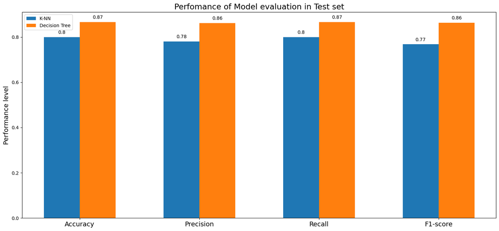

```python
# Perfomance comparing

# Data setting
knn_results = [accuracyknn_test,precisionknn_test, recallknn_test, f1knn_test]
decision_tree_results = [accuracyT_test,precisionT_test, recallT_test, f1T_test ]
values = ['Accuracy','Precision', 'Recall', 'F1-score']

# Setting up the plot parameters
bar_width = 0.30
index = np.arange(len(values))

# Plotting the graph
plt.figure(figsize=(15,7))

# Creating bar plots
plt.bar(index - bar_width/2, knn_results, bar_width, label='K-NN ')
plt.bar(index + bar_width/2, decision_tree_results, bar_width, label='Decision Tree')

# Adding data labels on top of the bars for clarity
for i in range(len(values)):
    plt.text(index[i] - bar_width/2, knn_results[i] + 0.01, str(round(knn_results[i], 2)), ha='center', va='bottom')
    plt.text(index[i] + bar_width/2, decision_tree_results[i] + 0.01, str(round(decision_tree_results[i], 2)), ha='center', va='bottom')

# Naming x, y and graph
plt.xlabel('')
plt.ylabel('Performance level',fontsize=14)
plt.title('Perfomance of Model evaluation in Test set',fontsize=17)
plt.xticks(index, values,fontsize=14)
plt.legend()

# Adjusting layout and displaying the plot
plt.tight_layout()
plt.show()
```

This bar graph show Performance Evaluation of Predictive Models for Heart Failure Patient Outcomes

In comparing the performance of K-Nearest Neighbors (KNN) and Decision Tree algorithms, the Decision Tree algorithm emerged as the superior model.

The Key Findings found that the Decision Tree model achieved higher accuracy on the test set, indicating better generalization to unseen data. It also outperformed KNN in precision, recall, F1-score, and robustness. Moreover,the Decision Tree's higher interpretability makes it easier for domain experts to understand the decision-making process. In additional, the model showed consistent performance between training and testing sets. Therefore,the Decision Tree algorithm is optimal for this dataset due to its superior accuracy and interpretability. It ensures this predictive analytics are effective and transparent, aiding in better decision-making and patient management for heart failure cases.